# Estadística I

clase 14: coeficiente de correlación de Pearson

Autor/a

Afiliación

M.Sc. José Miguel Avendaño I.

Universidad Central de Venezuela- Escuela de Economía. 2025-1

Fecha de publicación

3 de junio de 2025

## Coeficiente de Correlación de Pearson

- El **coeficiente de correlación de Pearson** ($r$) es una medida estadística que cuantifica la **fuerza** y la **dirección** de la relación lineal entre dos variables cuantitativas.
- Es una herramienta fundamental en estadística para entender cómo se mueven dos variables de un mismo cojunto de datos en distintas observaciones.
- El valor de $r$ siempre se encuentra entre -1 y +1.

## Interpretación del Coeficiente $r$

- $r > 0$: Indica una correlación **positiva**. A medida que una variable aumenta, la otra tiende a aumentar.
- $r < 0$: Indica una correlación **negativa**. A medida que una variable aumenta, la otra tiende a disminuir.
- $r \approx 0$: Indica una correlación **débil** o nula entre las variables.
- La magnitud de $r$ indica la fuerza de la relación lineal:
  - Cercano a $\pm 1$: Correlación lineal fuerte.
  - Cercano a 0: Correlación lineal débil.

## La Fórmula del Coeficiente de Correlación de Pearson

El coeficiente de correlación de Pearson se calcula mediante la siguiente fórmula:

$$r = \frac{\sum_{i=1}^{n} (x_i - \bar{x})(y_i - \bar{y})}{\sqrt{\sum_{i=1}^{n} (x_i - \bar{x})^2} \sqrt{\sum_{i=1}^{n} (y_i - \bar{y})^2}}$$

Donde: * $n$ es el número de pares de datos. * $x_i$ y $y_i$ son los valores individuales de las dos variables. * $\bar{x}$ es la media de los valores de $x$. * $\bar{y}$ es la media de los valores de $y$.

## Ejemplo de Cálculo

Consideremos el siguiente conjunto de datos sobre horas de estudio ($X$) y calificaciones obtenidas ($Y$):

| Estudiante | Horas de Estudio ($X$) | Calificación ($Y$) |
| --- | --- | --- |
| 1 | 2 | 5 |
| 2 | 3 | 7 |
| 3 | 4 | 8 |

## Gráfico de Dispersión

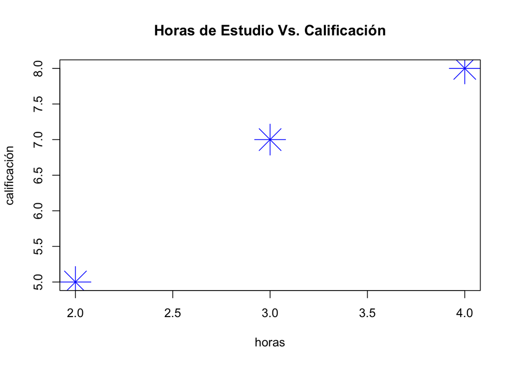

## Ejemplo de Cálculo-cont.

Vamos a calcular el coeficiente de correlación $r$.

Primero, calculamos las medias:

$$\bar{x} = \frac{2+3+4}{3} = 3$$

$$\bar{y} = \frac{5+7+8}{3} \approx 6.67$$

Luego, calculamos los términos necesarios para la fórmula:

## Ejemplo de Cálculo-cont.

| $x_i$ | $y_i$ | $x_i - \bar{x}$ | $y_i - \bar{y}$ | $(x_i - \bar{x})(y_i - \bar{y})$ | $(x_i - \bar{x})^2$ | $(y_i - \bar{y})^2$ |
| --- | --- | --- | --- | --- | --- | --- |
| 2 | 5 | -1 | -1.67 | 1.67 | 1 | 2.79 |
| 3 | 7 | 0 | 0.33 | 0 | 0 | 0.11 |
| 4 | 8 | 1 | 1.33 | 1.33 | 1 | 1.77 |
|  |  |  |  | $\sum = 3.00$ | $\sum = 2$ | $\sum = 4.67$ |

## Resultado del Ejemplo

Sustituyendo los valores en la fórmula:

$$r = \frac{3.00}{\sqrt{2} \sqrt{4.67}} = \frac{3.00}{\sqrt{9.34}} \approx \frac{3.00}{3.06} \approx 0.98$$

- El valor de $r \approx 0.98$ indica una **correlación lineal positiva muy fuerte** entre las horas de estudio y las calificaciones obtenidas en este pequeño conjunto de datos. Esto sugiere que a mayor número de horas de estudio, tiende a haber una mayor calificación.